# #10: 10/48 : 1 B -+ L

# 16 Fit to E-tag transitions

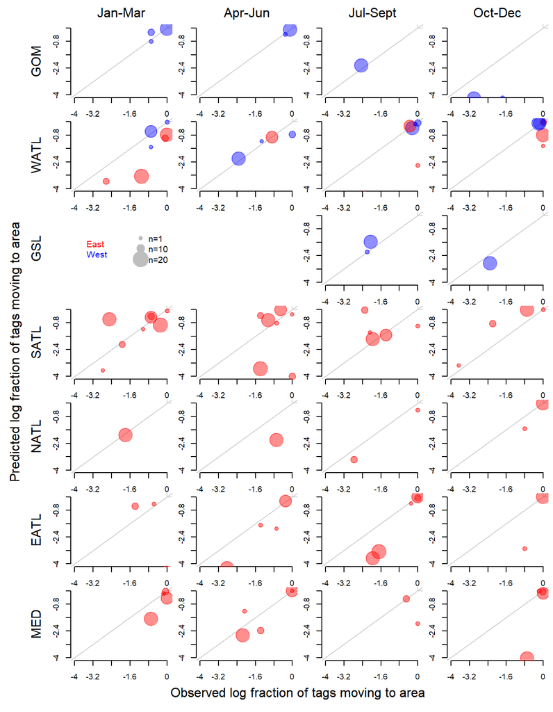

Figure 15a. The model fit to the observed log fractions of tags moving to the various areas by season. Red / blue points represent observed fraction of fish moving to an area of known eastern / western origin, respectively. The size of the bubble represents the number of tags moving. Although these plots summarize tagging transition data by area and season, these data are in fact disaggregated into strata by: area moving from (7 areas), area moving to (7 areas), season (4 quarters) and age class (3 age classes).

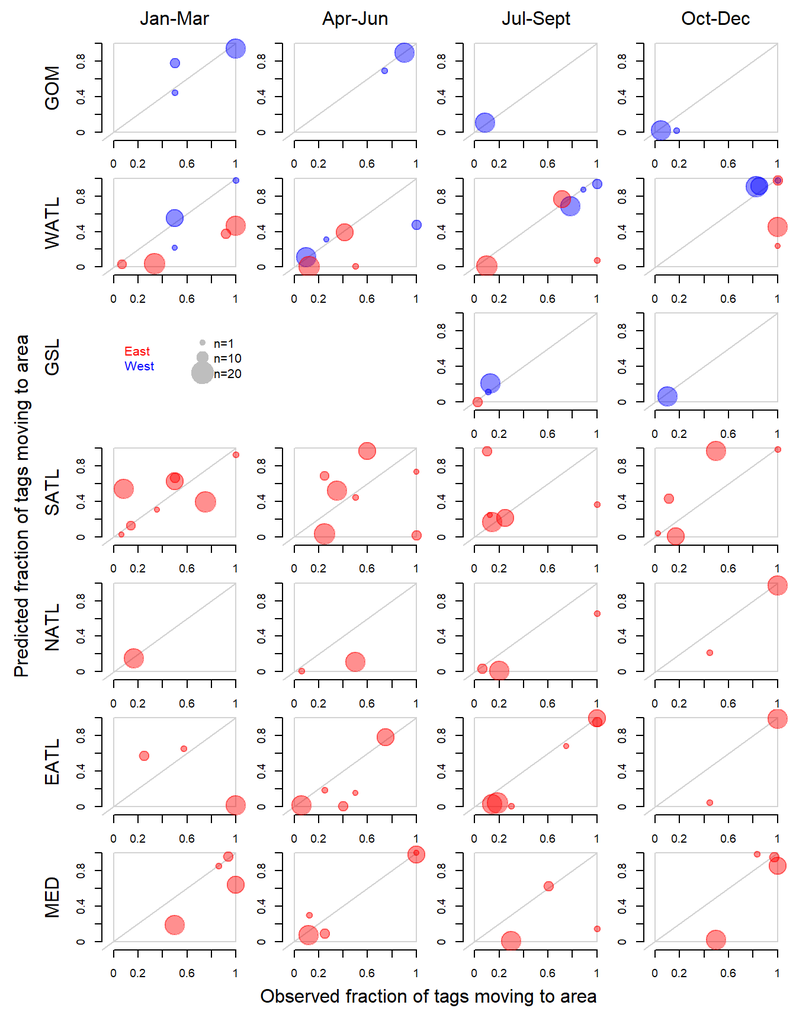

Figure 15b. As Figure 15a but showing real fractions (not log transformed)

# 17 Stock mixing

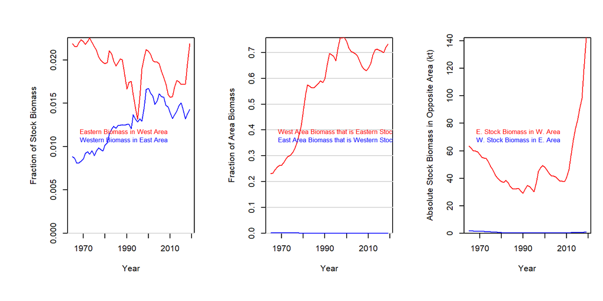

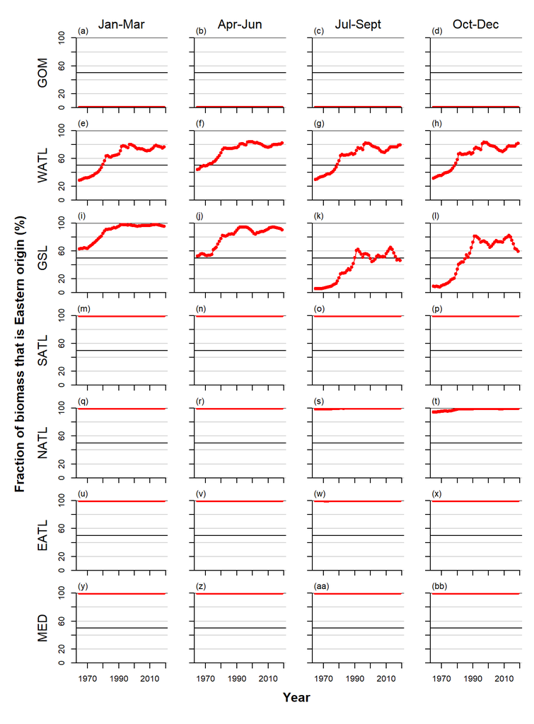

Figure 17a. Predicted stock mixing by year, season and area. The red line is the fraction (%) of stock biomass that is Eastern.

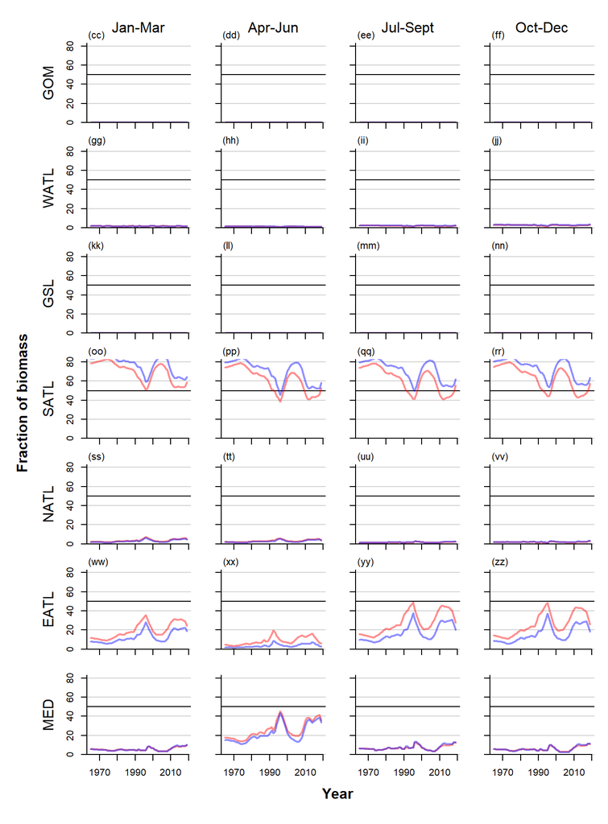

Figure 17b. Predicted spatial distribution of Eastern stock biomass by year and season. The red line is the fraction (%) of stock biomass found in each area, blue lines are spawning stock biomass.

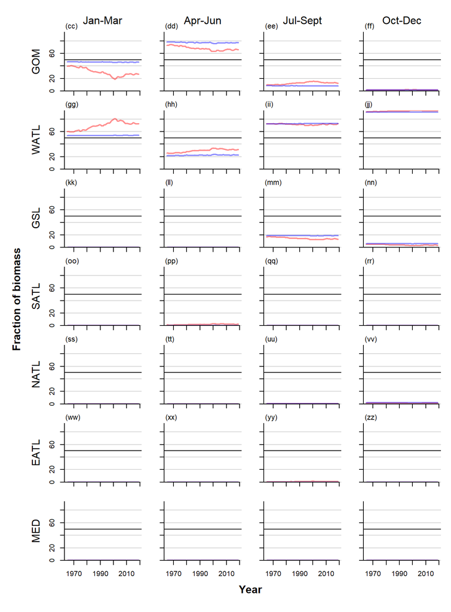

Figure 17c. Predicted spatial distribution of Western stock biomass by year and season. The red line is the fraction (%) of stock biomass found in each area,blue lines are spawning stock biomass.

# 18 Seasonal / spatial priors

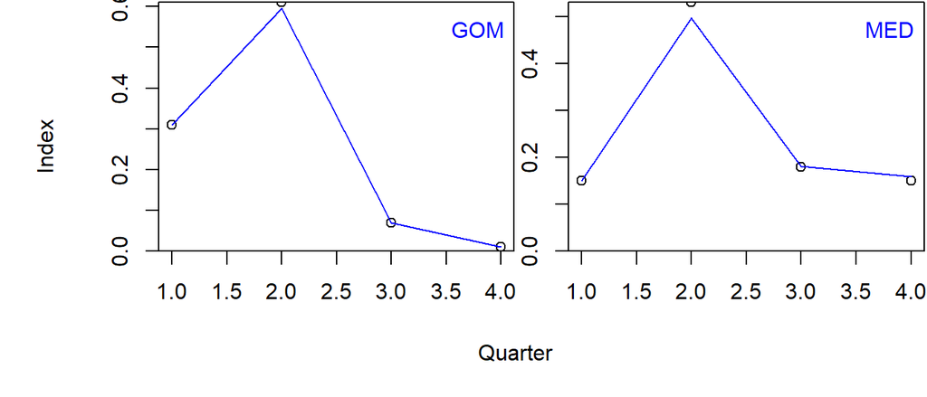

Figure 17d. Estimated seasonal distribution relative to prior specification.